# ci_post_clean

Autogenerated data summary from dataMaid

2023-10-06 11:43:27.532748

# Data report overview

The dataset examined has the following dimensions:

| Feature | Result |
| --- | --- |
| Number of observations | 470 |
| Number of variables | 44 |

### Checks performed

The following variable checks were performed, depending on the data type of each variable:

|  | character | factor | labelled | haven labelled | numeric | integer | logical | Date |
| --- | --- | --- | --- | --- | --- | --- | --- | --- |
| Identify miscoded missing values | × | × | × | × | × | × |  | × |
| Identify prefixed and suffixed whitespace | × | × | × | × |  |  |  |  |
| Identify levels with < 6 obs. | × | × | × | × |  |  |  |  |
| Identify case issues | × | × | × | × |  |  |  |  |
| Identify misclassified numeric or integer variables | × | × | × | × |  |  |  |  |
| Identify outliers |  |  |  |  | × | × |  | × |

Please note that all numerical values in the following have been rounded to 2 decimals.

# Summary table

|  | Variable class | # unique values | Missing observations | Any problems? |
| --- | --- | --- | --- | --- |
| X | integer | 470 | 0.00 % |  |
| Unnamed..0 | integer | 394 | 0.00 % |  |
| start | character | 470 | 0.00 % | × |
| end | character | 470 | 0.00 % | × |
| renewvia_id | character | 456 | 0.00 % | × |
| country | character | 2 | 0.00 % |  |
| kenya_community | character | 14 | 0.00 % | × |
| nigeria_community | character | 8 | 0.00 % | × |
| original_person | character | 4 | 0.00 % | × |
| connection_period_non_original_subscriber | character | 6 | 0.00 % | × |
| first_name | character | 353 | 0.00 % | × |
| last_name | character | 334 | 0.00 % | × |
| connection_period | character | 4 | 0.00 % | × |
| business_type | character | 5 | 0.00 % |  |
| institution_name | character | 223 | 0.00 % | × |
| operation_status | character | 4 | 0.00 % | × |
| closed_operations_explain | character | 41 | 0.00 % | × |
| non_renewvia_electrical_sources | character | 4 | 0.00 % | × |
| appliances_addition_type | character | 140 | 0.00 % | × |
| appliances_addition_explain | character | 107 | 0.00 % | × |
| kerosene_usage_change | character | 4 | 0.00 % | × |
| diesel_usage_change | character | 4 | 0.00 % | × |
| operations_hours_change | character | 3 | 0.00 % |  |
| business_hours_increase | character | 5 | 0.00 % | × |
| clean_drinking_water_access | character | 4 | 0.00 % | × |
| ci_offering_change | character | 2 | 0.00 % |  |
| new_prod_serv_add_explain | character | 196 | 0.00 % | × |
| workforce_change | character | 4 | 0.00 % | × |
| workforce_change_explain | character | 159 | 0.00 % | × |
| workforce_change_female | integer | 8 | 21.28 % | × |
| earnings_change | character | 4 | 0.00 % | × |
| ci_new_offering | character | 266 | 0.00 % | × |
| health_offering_change | character | 16 | 0.00 % | × |
| clinic_offering_unable_prior_minigrid | character | 25 | 0.00 % | × |
| school_attendance_change | character | 3 | 0.00 % | × |
| school_offering_unable_prior_minigrid | character | 42 | 0.00 % | × |
| school_performance | character | 3 | 0.00 % | × |
| minigrid_benefits | character | 433 | 0.00 % | × |
| minigrid_problems | character | 276 | 0.00 % | × |
| end_date | character | 34 | 0.00 % | × |
| customerAccountNumber | numeric | 363 | 21.06 % |  |
| tariff | character | 4 | 0.00 % | × |
| appliances_addition_count | integer | 9 | 0.00 % |  |
| health_offering_change_count | integer | 6 | 0.00 % |  |

# Variable list

## X

| Feature | Result |
| --- | --- |
| Variable type | integer |
| Number of missing obs. | 0 (0 %) |
| Number of unique values | 470 |
| Median | 234.5 |
| 1st and 3rd quartiles | 117.25; 351.75 |
| Min. and max. | 0; 469 |

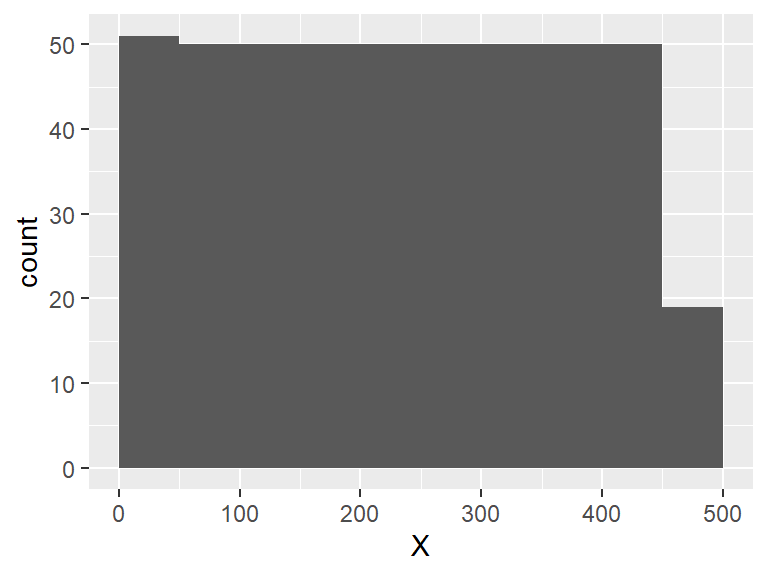

## Unnamed..0

| Feature | Result |
| --- | --- |
| Variable type | integer |
| Number of missing obs. | 0 (0 %) |
| Number of unique values | 394 |
| Median | 158.5 |
| 1st and 3rd quartiles | 58.25; 275.75 |
| Min. and max. | 0; 393 |

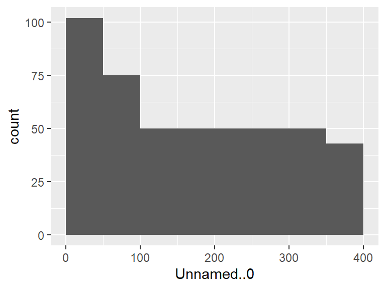

## start

- The variable is a key (distinct values for each observation).

## end

- The variable is a key (distinct values for each observation).

## renewvia_id

| Feature | Result |
| --- | --- |
| Variable type | character |
| Number of missing obs. | 0 (0 %) |
| Number of unique values | 456 |
| Mode | “rn2265” |

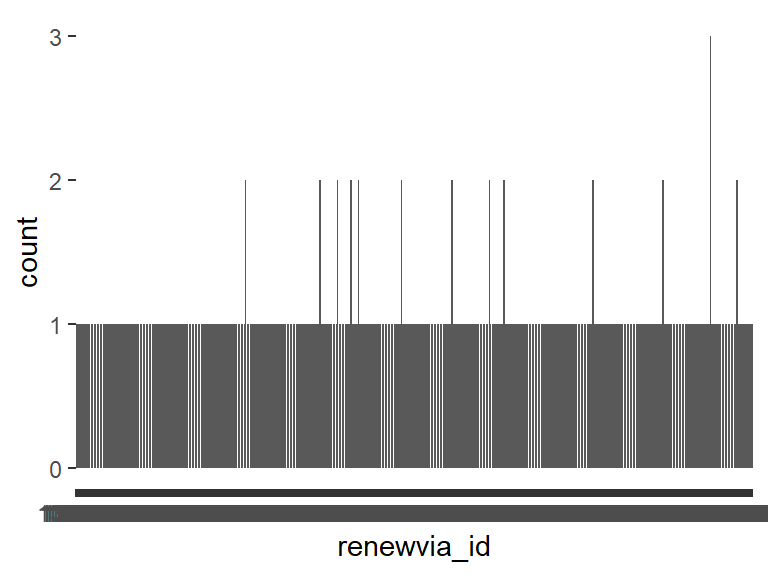

- The following values appear with prefixed or suffixed white space: "242331 ".
- Note that the following levels have at most five observations: "131101", "131106", "131107", "131111", "131112", …, "rn2691", "rn2692", "rn2701", "rn2803", "rn2835" (446 values omitted).

## country

| Feature | Result |
| --- | --- |
| Variable type | character |
| Number of missing obs. | 0 (0 %) |
| Number of unique values | 2 |
| Mode | “kenya” |

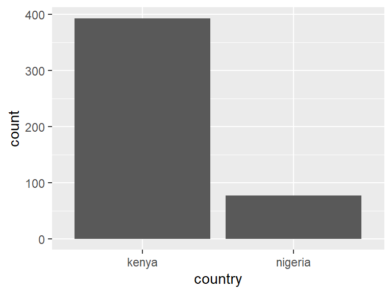

## kenya_community

| Feature | Result |
| --- | --- |
| Variable type | character |
| Number of missing obs. | 0 (0 %) |
| Number of unique values | 14 |
| Mode | “kalobeyei_settlement” |

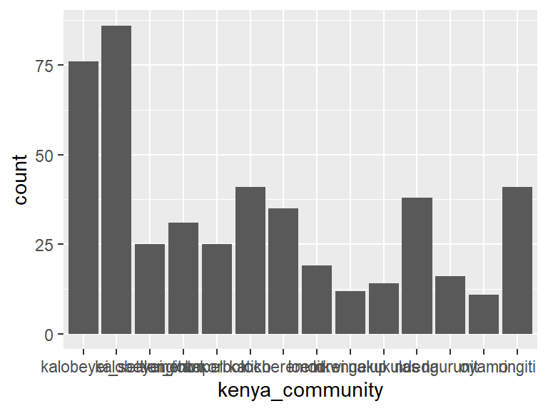

- The following suspected missing value codes enter as regular values: "".

## nigeria_community

| Feature | Result |
| --- | --- |
| Variable type | character |
| Number of missing obs. | 0 (0 %) |
| Number of unique values | 8 |
| Mode | “” |

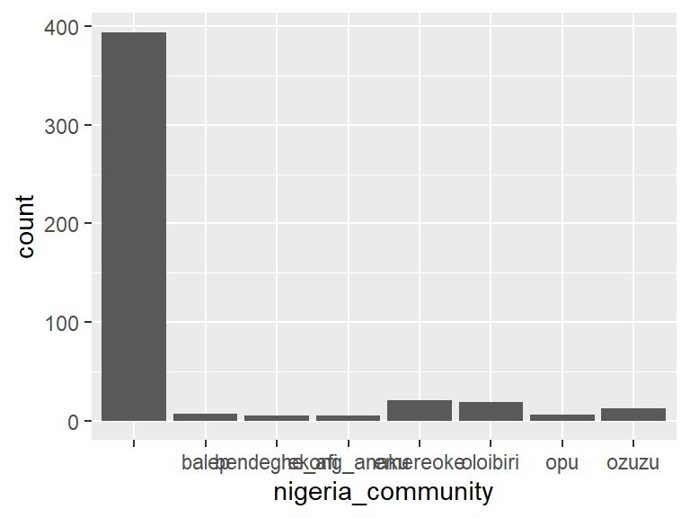

- The following suspected missing value codes enter as regular values: "".
- Note that the following levels have at most five observations: "bendeghe_afi", "ekong_anaku".

## original_person

| Feature | Result |
| --- | --- |
| Variable type | character |
| Number of missing obs. | 0 (0 %) |
| Number of unique values | 4 |
| Mode | “yes” |

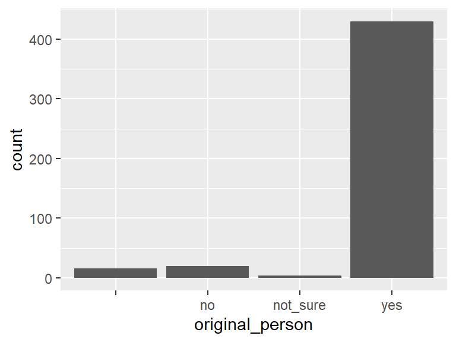

- The following suspected missing value codes enter as regular values: "".
- Note that the following levels have at most five observations: "not_sure".

## connection_period_non_original_subscriber

| Feature | Result |
| --- | --- |
| Variable type | character |
| Number of missing obs. | 0 (0 %) |
| Number of unique values | 6 |
| Mode | “more_than_24_months” |

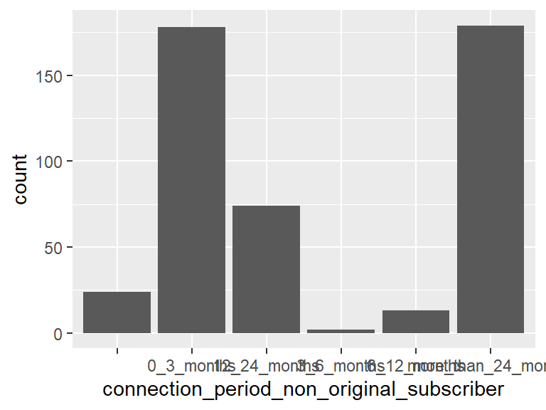

- The following suspected missing value codes enter as regular values: "".
- Note that the following levels have at most five observations: "3_6_months".

## first_name

| Feature | Result |
| --- | --- |
| Variable type | character |
| Number of missing obs. | 0 (0 %) |
| Number of unique values | 353 |
| Mode | “” |

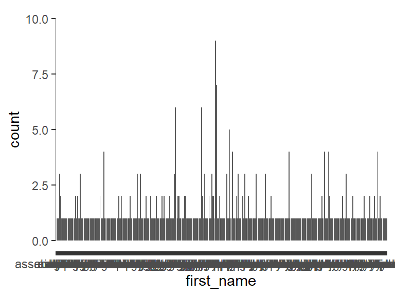

- The following suspected missing value codes enter as regular values: "".
- The following values appear with prefixed or suffixed white space: "abdi ", "abraham ", "adam ", "adil ", "akiru ", …, "veronica ", "wfp ", "yehova ", "yusuf ", "zeinab " (87 values omitted).
- Note that the following levels have at most five observations: "aahi", "abdi ", "abraham ", "adam", "adam ", …, "wole", "yehova ", "yonah", "yusuf ", "zeinab " (338 values omitted).

## last_name

| Feature | Result |
| --- | --- |
| Variable type | character |
| Number of missing obs. | 0 (0 %) |
| Number of unique values | 334 |
| Mode | “” |

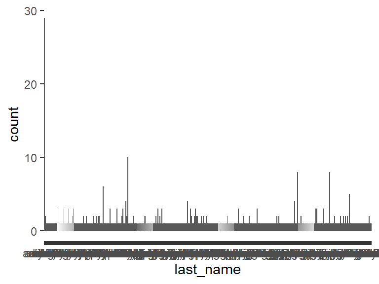

- The following suspected missing value codes enter as regular values: "".
- The following values appear with prefixed or suffixed white space: "aila ", "church ", "gas’s ", "health center ", "ochieng ", "primary school ".
- Note that the following levels have at most five observations: "abdal", "abdi", "abiori", "abo", "achieng", …, "water", "winrose", "witness", "yakob", "yiayia" (319 values omitted).

## connection_period

| Feature | Result |
| --- | --- |
| Variable type | character |
| Number of missing obs. | 0 (0 %) |
| Number of unique values | 4 |
| Mode | “longer_than_2_years” |

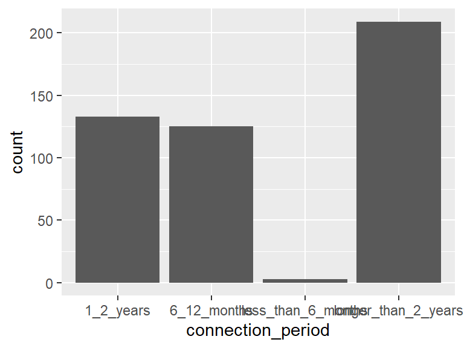

- Note that the following levels have at most five observations: "less_than_6_months".

## business_type

| Feature | Result |
| --- | --- |
| Variable type | character |
| Number of missing obs. | 0 (0 %) |
| Number of unique values | 5 |
| Mode | “shop” |

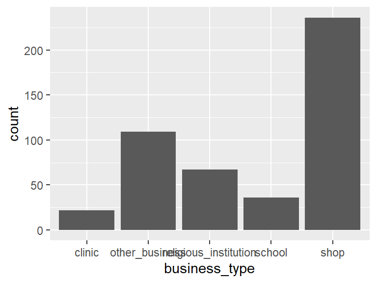

## institution_name

| Feature | Result |
| --- | --- |
| Variable type | character |
| Number of missing obs. | 0 (0 %) |
| Number of unique values | 223 |
| Mode | “no name” |

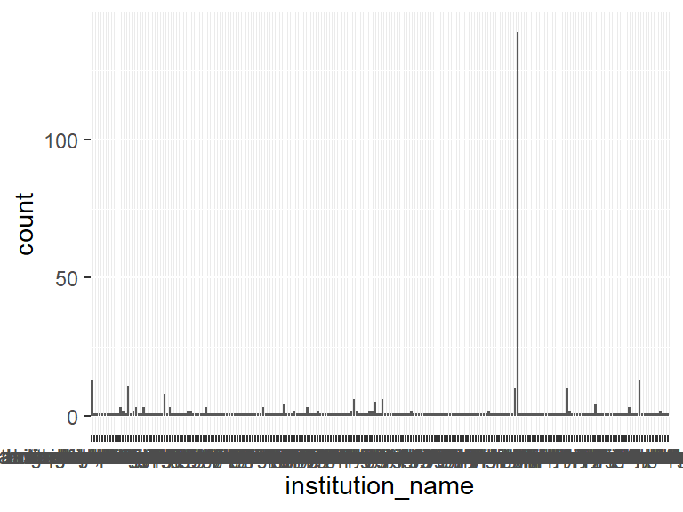

- The following suspected missing value codes enter as regular values: "".
- The following values appear with prefixed or suffixed white space: " catholic church kagitankori", "aic ngurunit church ", "akiberano enterprises ", "bar/restaurant ", "church ", …, "ngurunit secondary school ", "saloto primary ", "secondary tuition block ", "video hall ", "wambile shop " (5 values omitted).
- Note that the following levels have at most five observations: " catholic church kagitankori", "aic church", "aic ngurunit church ", "akiberano enterprises ", "antioch baptist church", …, "winners chapel bendeghe-afi", "workshop", "yehova witness church kagitankori", "zeinab shop", "zkiz mobile charging" (204 values omitted).

## operation_status

| Feature | Result |
| --- | --- |
| Variable type | character |
| Number of missing obs. | 0 (0 %) |
| Number of unique values | 4 |
| Mode | “yes_we_are_still_operating” |

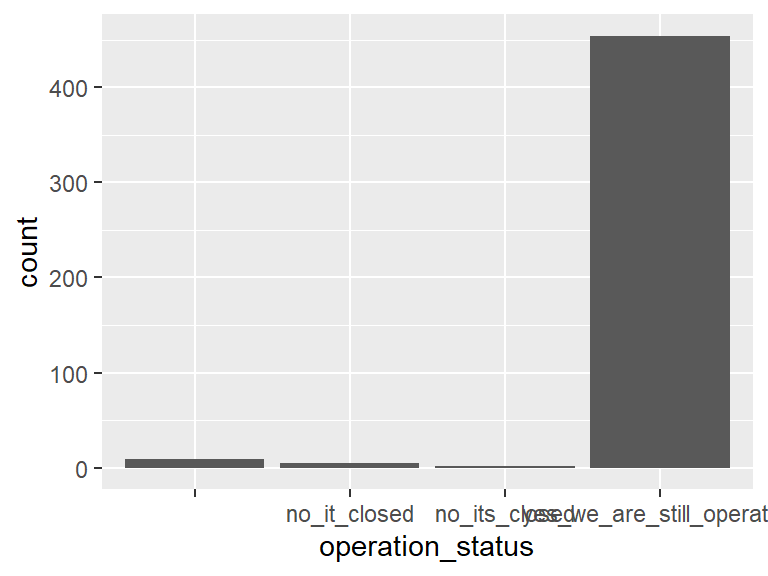

- The following suspected missing value codes enter as regular values: "".
- Note that the following levels have at most five observations: "no_it_closed", "no_its_closed".

## closed_operations_explain

| Feature | Result |
| --- | --- |
| Variable type | character |
| Number of missing obs. | 0 (0 %) |
| Number of unique values | 41 |
| Mode | “operational” |

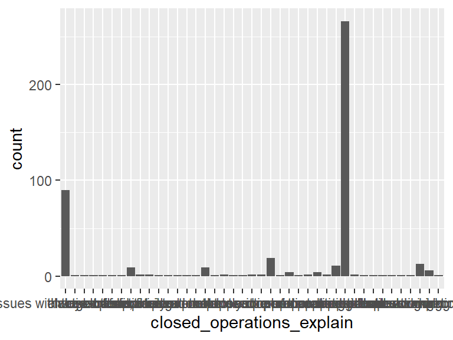

- The following suspected missing value codes enter as regular values: "".
- The following values appear with prefixed or suffixed white space: "none ", "open ", "operating ", "operational ", "working ".
- Note that the following levels have at most five observations: "active", "always open", "change of shop", "closed", "closed temporarily", …, "still operating", "still operational", "still working", "too much of sales competion in the area", "workong" (23 values omitted).

## non_renewvia_electrical_sources

| Feature | Result |
| --- | --- |
| Variable type | character |
| Number of missing obs. | 0 (0 %) |
| Number of unique values | 4 |
| Mode | “no_just_renewvia_minigrid” |

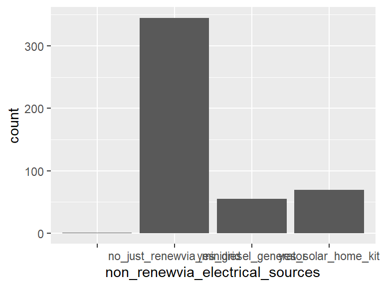

- The following suspected missing value codes enter as regular values: "".
- Note that the following levels have at most five observations: "".

## appliances_addition_type

| Feature | Result |
| --- | --- |
| Variable type | character |
| Number of missing obs. | 0 (0 %) |
| Number of unique values | 140 |
| Mode | “interior lights;exterior lights;no additional appliances;” |

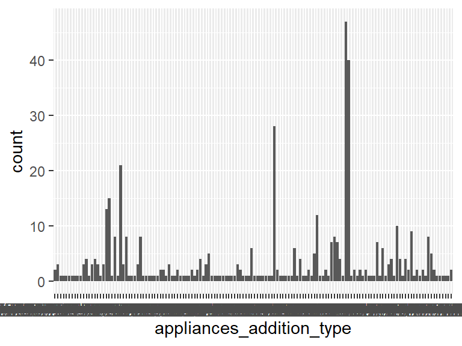

- The following suspected missing value codes enter as regular values: "".
- Note that the following levels have at most five observations: "", "cold storage - refrigerator or freezer", "cold storage - refrigerator or freezer;", "cold storage - refrigerator or freezer;computer or tv;exterior lights;interior lights;", "cold storage - refrigerator or freezer;computer or tv;fan;", …, "other electronic device;", "other electronic device;cold storage - refrigerator or freezer;interior lights;exterior lights;fan;", "other electronic device;computer or tv;fan;exterior lights;interior lights;cold storage - refrigerator or freezer;", "other electronic device;computer or tv;interior lights;", "other electronic device;interior lights;" (110 values omitted).

## appliances_addition_explain

| Feature | Result |
| --- | --- |
| Variable type | character |
| Number of missing obs. | 0 (0 %) |
| Number of unique values | 107 |
| Mode | “” |

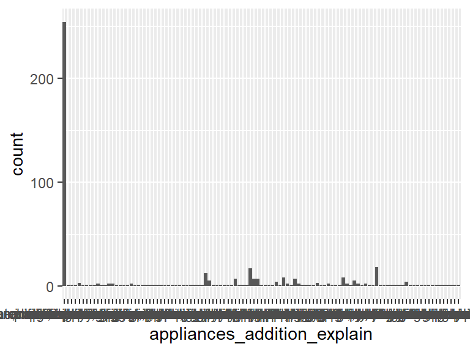

- The following suspected missing value codes enter as regular values: "".
- The following values appear with prefixed or suffixed white space: "chargers ", "charging ", "electric machine for weights ", "music system ", "no other appliance ", …, "public addres ", "public address ", "public address system ", "radio, refridgirators, tv, ", "water dispenser " (5 values omitted).
- Note that the following levels have at most five observations: "ac, microscope, centrifugal machine, photocopier", "air conditioner", "amplifier, electri iron", "amplifier, speakers and mic", "amplifier, speakers, mic", …, "television, phone charger", "water dispenser", "water dispenser ", "welding machine", "welding machines, pluster machines" (87 values omitted).

## kerosene_usage_change

| Feature | Result |
| --- | --- |
| Variable type | character |
| Number of missing obs. | 0 (0 %) |
| Number of unique values | 4 |
| Mode | “yes_it_has_decreased” |

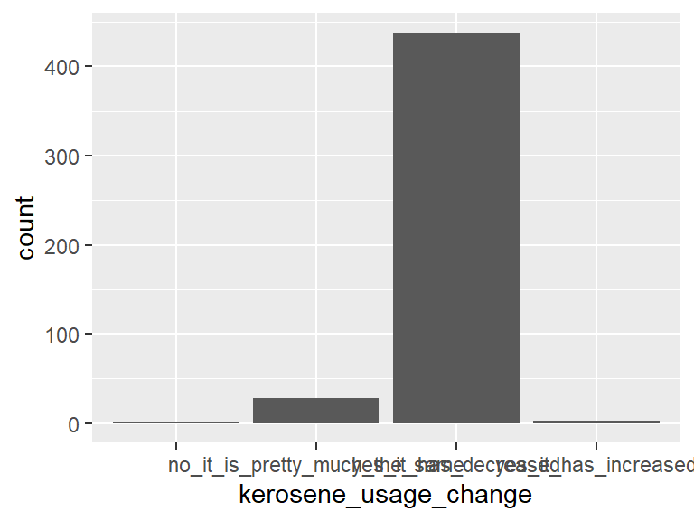

- The following suspected missing value codes enter as regular values: "".
- Note that the following levels have at most five observations: "", "yes_it_has_increased".

## diesel_usage_change

| Feature | Result |
| --- | --- |
| Variable type | character |
| Number of missing obs. | 0 (0 %) |
| Number of unique values | 4 |
| Mode | “yes_it_has_decreased” |

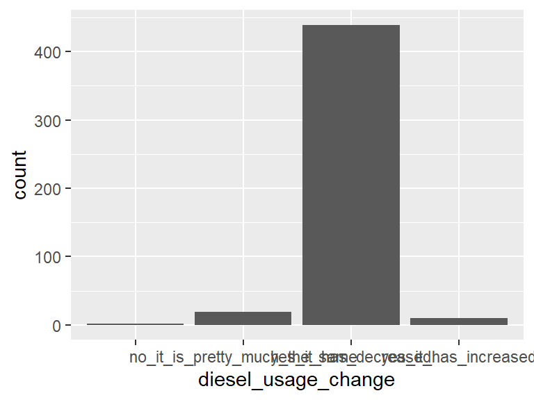

- The following suspected missing value codes enter as regular values: "".
- Note that the following levels have at most five observations: "".

## operations_hours_change

| Feature | Result |
| --- | --- |
| Variable type | character |
| Number of missing obs. | 0 (0 %) |
| Number of unique values | 3 |
| Mode | “yes_they_have_increased” |

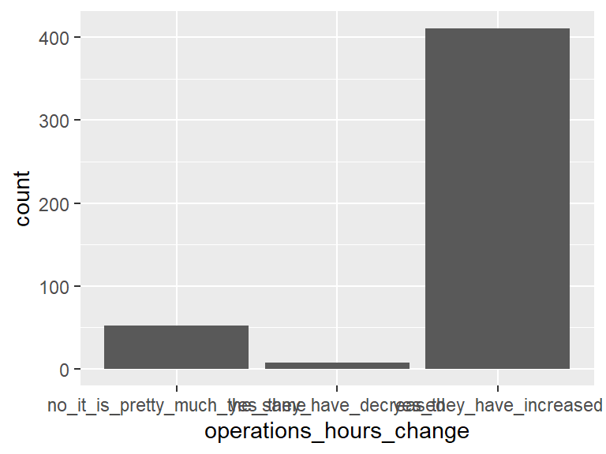

## business_hours_increase

| Feature | Result |
| --- | --- |
| Variable type | character |
| Number of missing obs. | 0 (0 %) |
| Number of unique values | 5 |
| Mode | “1_2_hours_daily” |

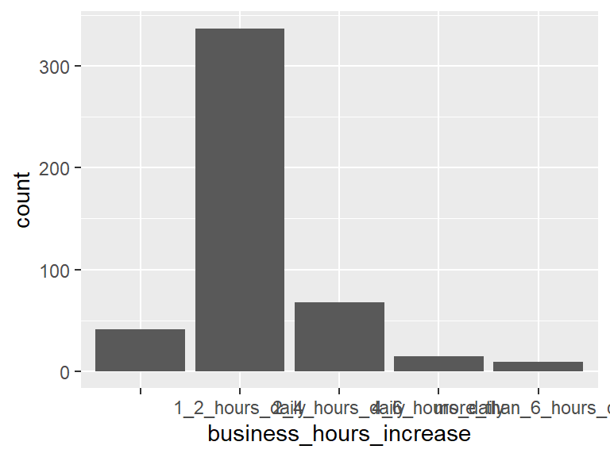

- The following suspected missing value codes enter as regular values: "".

## clean_drinking_water_access

| Feature | Result |
| --- | --- |
| Variable type | character |
| Number of missing obs. | 0 (0 %) |
| Number of unique values | 4 |
| Mode | “no_it_is_pretty_much_the_same” |

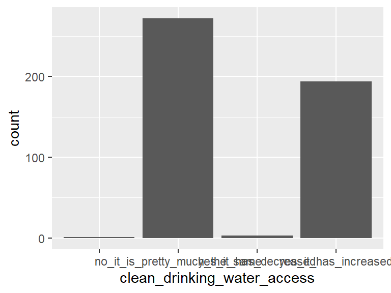

- The following suspected missing value codes enter as regular values: "".
- Note that the following levels have at most five observations: "", "yes_it_has_decreased".

## ci_offering_change

| Feature | Result |
| --- | --- |
| Variable type | character |
| Number of missing obs. | 0 (0 %) |
| Number of unique values | 2 |
| Mode | “yes” |

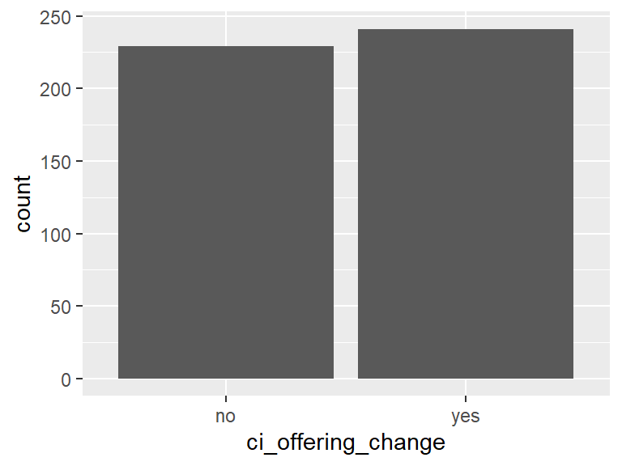

## new_prod_serv_add_explain

| Feature | Result |
| --- | --- |
| Variable type | character |
| Number of missing obs. | 0 (0 %) |
| Number of unique values | 196 |
| Mode | “” |

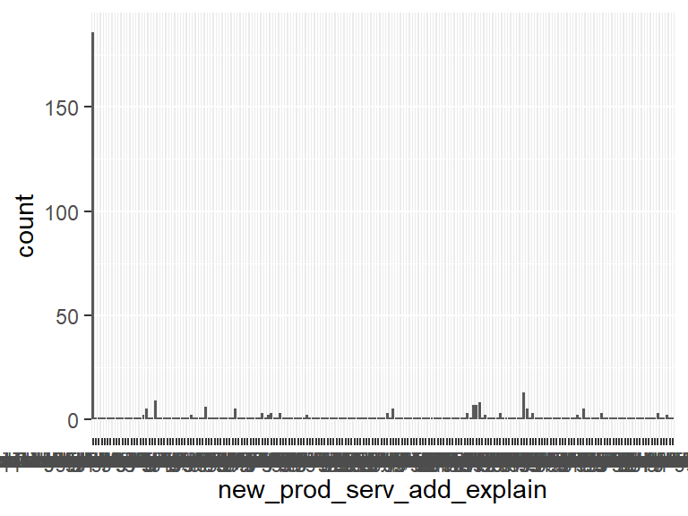

- The following suspected missing value codes enter as regular values: "".
- The following values appear with prefixed or suffixed white space: "addition of part time lessons ", "better n fast services ", "charging ", "charging services ", "church instruments ", …, "morning glory and night vigils ", "none ", "not yet added ", "phone charging ", "printers, laminators and whoofer " (7 values omitted).
- Note that the following levels have at most five observations: "24 hour operation", "added other appliances due to customer demand", "added stock", "added water dispenser", "addition of part time lessons ", …, "tution for interested individuals", "tution for some students", "tv, radio", "vaccines administering unlike before", "we have added refrigerator to aid preserve drugs" (179 values omitted).

## workforce_change

| Feature | Result |
| --- | --- |
| Variable type | character |
| Number of missing obs. | 0 (0 %) |
| Number of unique values | 4 |
| Mode | “no_the_number_has_remained_the_same” |

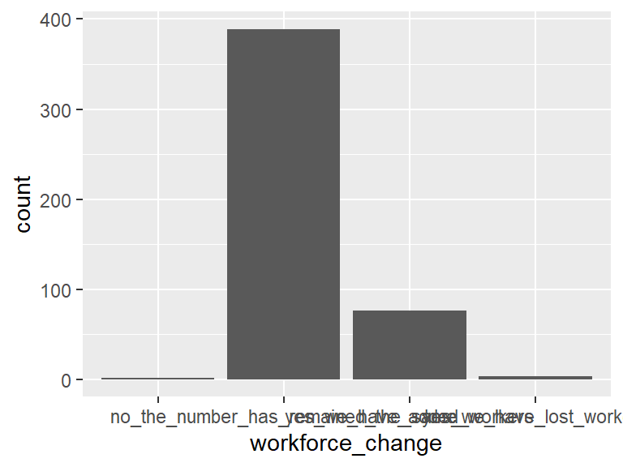

- The following suspected missing value codes enter as regular values: "".
- Note that the following levels have at most five observations: "", "yes_we_have_lost_workers".

## workforce_change_explain

| Feature | Result |
| --- | --- |
| Variable type | character |
| Number of missing obs. | 0 (0 %) |
| Number of unique values | 159 |
| Mode | “” |

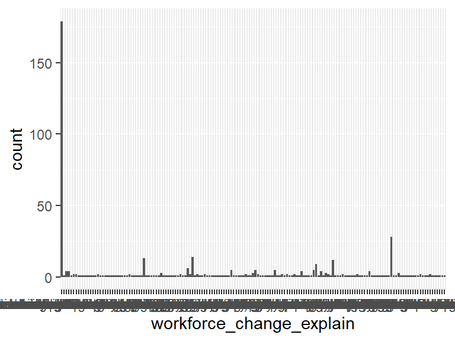

- The following suspected missing value codes enter as regular values: "".
- The following values appear with prefixed or suffixed white space: " having enough", "constant number ", "cook and security personnel ", "enough ", "have enough ", …, "not needed ", "same number ", "still same ", "we reduce our operation team since products were not enough due to fundings ", "yes workers has increased " (8 values omitted).
- Note that the following levels have at most five observations: " having enough", "0", "1", "10", "2", …, "working with available number", "working with initia number", "working with initial number", "working with the available number", "yes workers has increased " (142 values omitted).

## workforce_change_female

| Feature | Result |
| --- | --- |
| Variable type | integer |
| Number of missing obs. | 100 (21.28 %) |
| Number of unique values | 7 |
| Median | 0 |
| 1st and 3rd quartiles | 0; 0 |
| Min. and max. | 0; 6 |

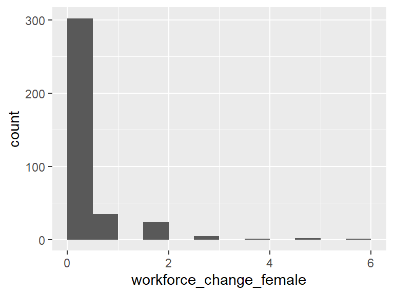

- Note that the following possible outlier values were detected: "1", "2", "3", "4", "5", "6".

## earnings_change

| Feature | Result |
| --- | --- |
| Variable type | character |
| Number of missing obs. | 0 (0 %) |
| Number of unique values | 4 |
| Mode | “yes_they_have_increased” |

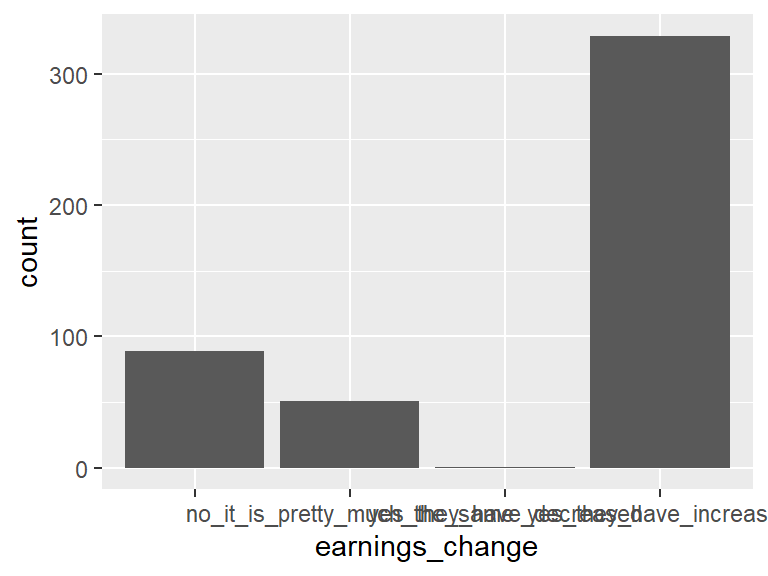

- The following suspected missing value codes enter as regular values: "".
- Note that the following levels have at most five observations: "yes_they_have_decreased".

## ci_new_offering

| Feature | Result |
| --- | --- |
| Variable type | character |
| Number of missing obs. | 0 (0 %) |
| Number of unique values | 266 |
| Mode | “” |

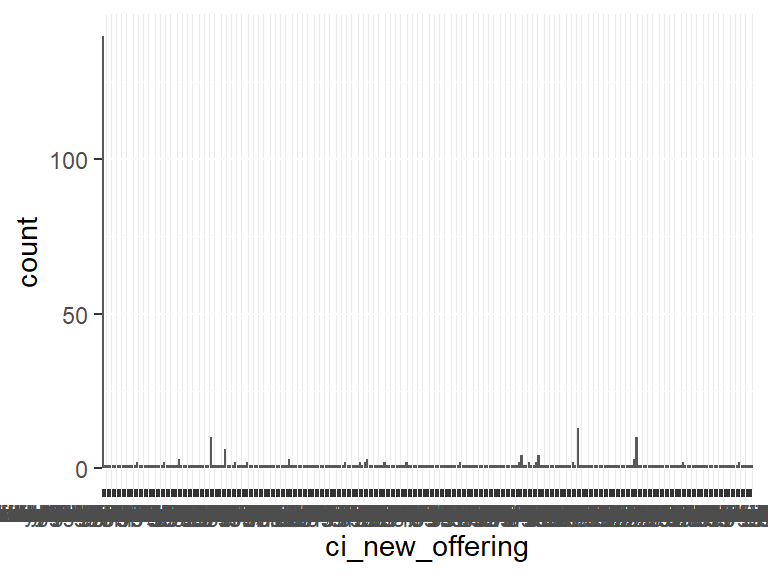

- The following suspected missing value codes enter as regular values: "".
- The following values appear with prefixed or suffixed white space: "added phone charging services ", "all products ", "barber services and salon alongside phone charging ", "better services ", "butchery ", …, "offering drinks as per customer wants and charging ", "offering variety of service ", "phone charging ", "phone charging, cold storage ", "refrigeration services " (14 values omitted).
- Note that the following levels have at most five observations: "a more reliable service", "ability to satisfy my clients", "ability to work all through", "able to offer charging services", "able to preserve and offer cold services", …, "well services", "wholesale n retail, cold drinks", "wholesale shop", "working longer", "working longer hours" (251 values omitted).

## health_offering_change

| Feature | Result |
| --- | --- |
| Variable type | character |
| Number of missing obs. | 0 (0 %) |
| Number of unique values | 16 |
| Mode | “” |

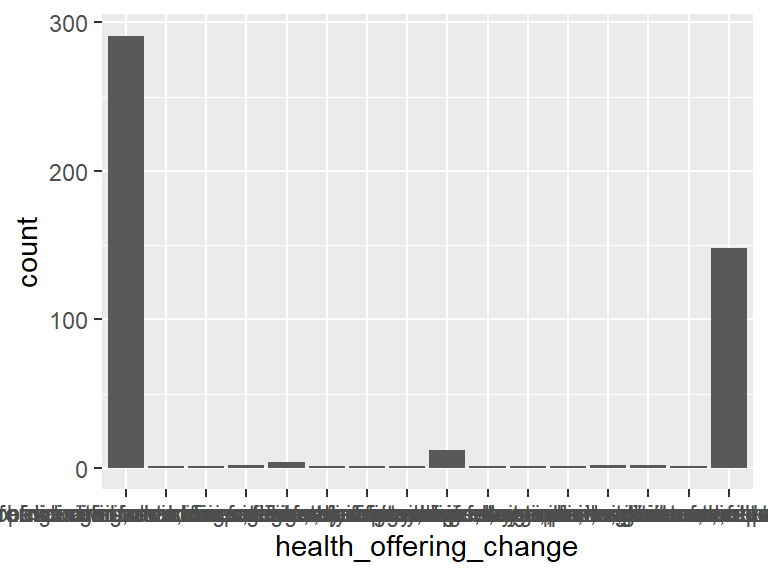

- The following suspected missing value codes enter as regular values: "".
- Note that the following levels have at most five observations: "clinic can see more patients;", "clinic can see more patients;clinic stays open longer hours;clinic now has a refrigerator for vaccines;wait times are shorter;", "clinic now has a refrigerator for vaccines", "clinic now has a refrigerator for vaccines;", "clinic now has a refrigerator for vaccines;clinic can see more patients;clinic stays open longer hours;wait times are shorter;", …, "clinic now has a refrigerator for vaccines;wait times are shorter;clinic can see more patients;", "clinic stays open longer hours", "clinic stays open longer hours;clinic can see more patients;", "clinic stays open longer hours;clinic can see more patients;wait times are shorter;", "none of these" (3 values omitted).

## clinic_offering_unable_prior_minigrid

| Feature | Result |
| --- | --- |
| Variable type | character |
| Number of missing obs. | 0 (0 %) |
| Number of unique values | 25 |
| Mode | “” |

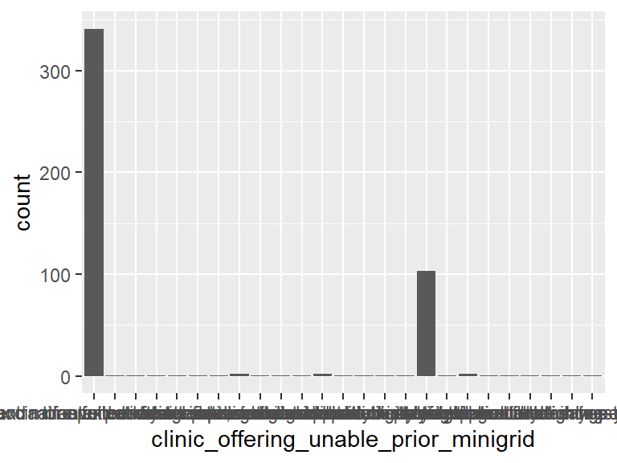

- The following suspected missing value codes enter as regular values: "".
- The following values appear with prefixed or suffixed white space: "faster patient attendance due to up to time systems ", "more patient attendance ", "refrigeration and lighting ", "well functioning system ".
- Note that the following levels have at most five observations: "available vaccination and carrying out various tests", "availed vaccines", "extended services", "extra time for service and patient attendance", "faster and more patient attendance, vaccines provided in plenty", …, "refrigeration and lighting ", "staying longer to attain to petience", "still the same", "well functioning system ", "yes" (13 values omitted).

## school_attendance_change

| Feature | Result |
| --- | --- |
| Variable type | character |
| Number of missing obs. | 0 (0 %) |
| Number of unique values | 3 |
| Mode | “” |

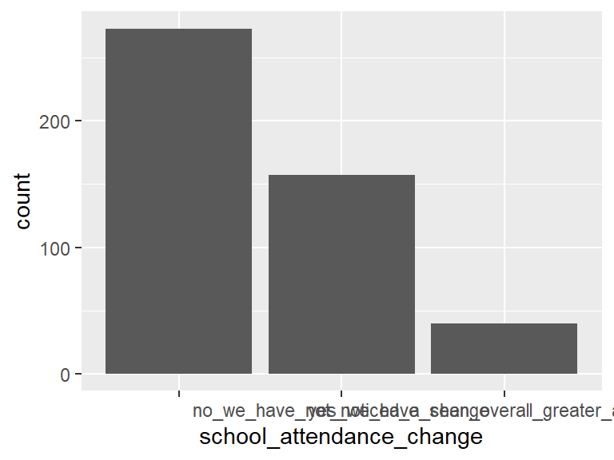

- The following suspected missing value codes enter as regular values: "".

## school_offering_unable_prior_minigrid

| Feature | Result |
| --- | --- |
| Variable type | character |
| Number of missing obs. | 0 (0 %) |
| Number of unique values | 42 |
| Mode | “” |

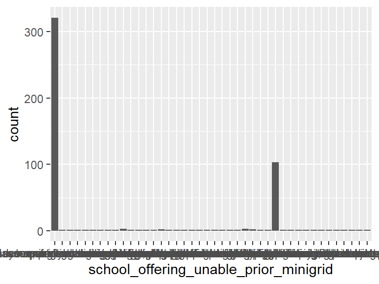

- The following suspected missing value codes enter as regular values: "".
- The following values appear with prefixed or suffixed white space: "an automated record keeping ", "night preps and exam typing and printing ", "printing services and evening preps ", "they will perform well and post good results ".
- Note that the following levels have at most five observations: "an automated record keeping ", "classes apart from the normal ones", "computer classes and tution", "early morning and lete evening lessons", "early morning classes", …, "they will perform well and post good results ", "tution classes", "tution classes but not daily", "we can offer early and late learning, good communication, ability to do out own printouts", "we use the minigrid power to pump water in the school" (30 values omitted).

## school_performance

| Feature | Result |
| --- | --- |
| Variable type | character |
| Number of missing obs. | 0 (0 %) |
| Number of unique values | 3 |
| Mode | “” |

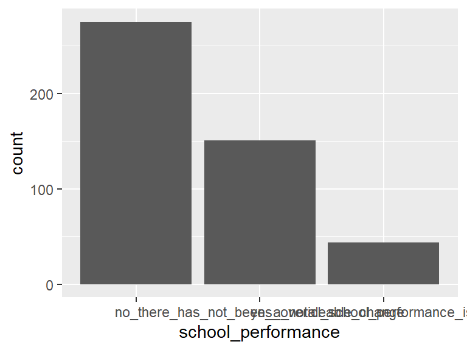

- The following suspected missing value codes enter as regular values: "".

## minigrid_benefits

| Feature | Result |
| --- | --- |
| Variable type | character |
| Number of missing obs. | 0 (0 %) |
| Number of unique values | 433 |
| Mode | “good services” |

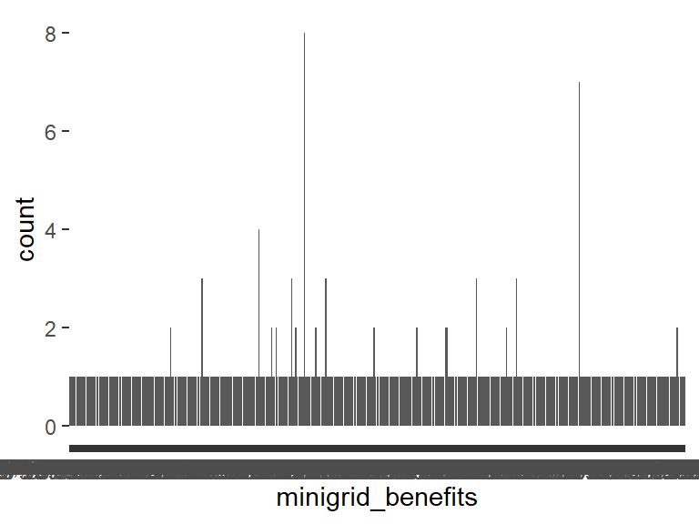

- The following suspected missing value codes enter as regular values: "".
- The following values appear with prefixed or suffixed white space: "able to extend closing hours ", "added more service and assured security ", "added more work time ", "attending patients late night till dawn due to lighting ", "availability of security and extra sales time ", …, "security and reliable ", "security well provided ", "stable power supply, notable change in the security ", "very reliable ", "we conduct services smoothly " (37 values omitted).
- Note that the following levels have at most five observations: "", "1.it does not fail during church programs us like generator\n2. it has brought development \n3. i use my electronic devices in my home and live in comfort", "ability to operate longer", "ability to satisfy customers", "able to achieve what was not known by many, reliable power source", …, "we work longer hours", "well conducted services", "work with confidence due to availed security lights, more time to work", "working hours extended", "yes just connected and started enjoying good lighting" (421 values omitted).

## minigrid_problems

| Feature | Result |
| --- | --- |
| Variable type | character |
| Number of missing obs. | 0 (0 %) |
| Number of unique values | 276 |
| Mode | “” |

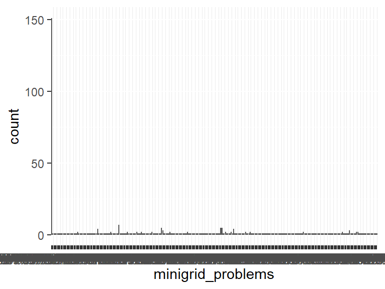

- The following suspected missing value codes enter as regular values: "".
- The following values appear with prefixed or suffixed white space: "atime high charges ", "atimes unreliable and delays after payment ", "available for short hours ", "delayed payment update and high rates ", "dissapoints atimes and high unit consumption ", …, "unreliable ", "unstable atimes and high tarifs ", "very expensive ", "very expressive ", "very high charges and has not been in use for quite some time " (23 values omitted).
- Note that the following levels have at most five observations: "1. the light comes on at the wrong time\n2. we need street lights", "1. we need extension in the period of light. we need a 24 hour service\n2. the tariff is too high\n3. the company need to re-equip or add to their system, because it seems this current one is depreciating", "a fault in one home affects the whole community, this can be annoying sometimes, at any point in time the light can shut down", "affected by weather mostly", "although the minigrid is still better compered to petrol generator but the tariff is high especially to me using refrigerator for business", …, "very high rates", "very high tariffs", "very high tarifs for commercial users, delays after payments and no accountability of power consumption and payments", "we need the light more often during our meetings and the tariff should be reduced.", "we need the light more often, especially on sundays" (264 values omitted).

## end_date

| Feature | Result |
| --- | --- |
| Variable type | character |
| Number of missing obs. | 0 (0 %) |
| Number of unique values | 34 |
| Mode | “2022-12-17” |

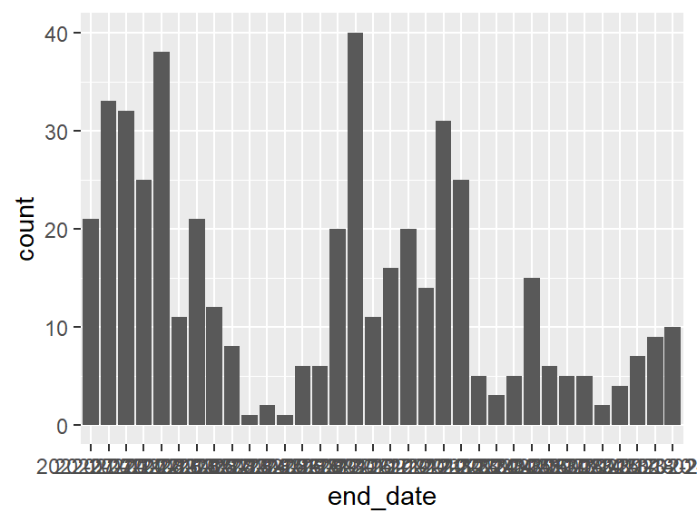

- Note that the following levels have at most five observations: "2022-08-25", "2022-08-26", "2022-08-28", "2023-02-04", "2023-02-05", "2023-02-06", "2023-02-14", "2023-02-15", "2023-02-17", "2023-02-18".

## customerAccountNumber

| Feature | Result |
| --- | --- |
| Variable type | numeric |
| Number of missing obs. | 99 (21.06 %) |
| Number of unique values | 362 |
| Median | 201122 |
| 1st and 3rd quartiles | 141128.5; 252122 |
| Min. and max. | 131101; 570141 |

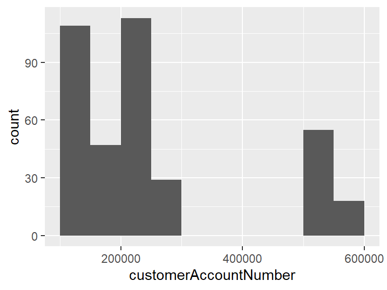

## tariff

| Feature | Result |
| --- | --- |
| Variable type | character |
| Number of missing obs. | 0 (0 %) |
| Number of unique values | 4 |
| Mode | “commercial” |

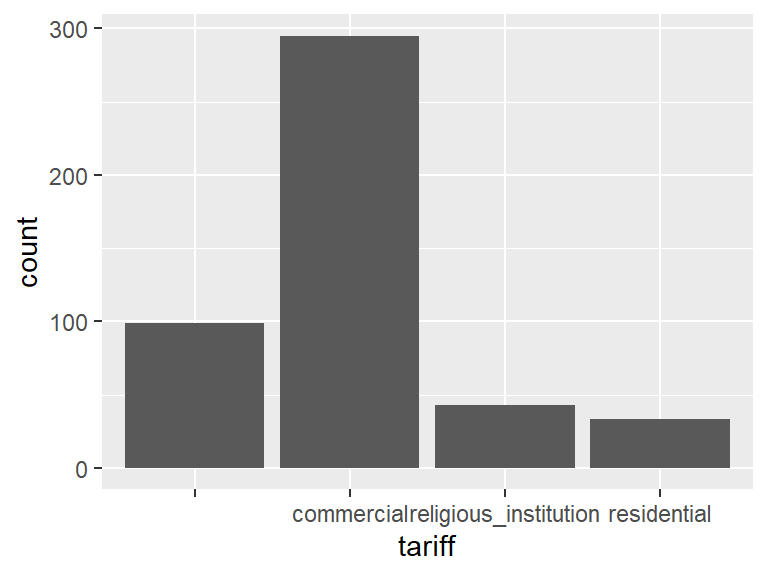

- The following suspected missing value codes enter as regular values: "".

## appliances_addition_count

| Feature | Result |
| --- | --- |
| Variable type | integer |
| Number of missing obs. | 0 (0 %) |
| Number of unique values | 9 |
| Median | 4 |
| 1st and 3rd quartiles | 3; 5 |
| Min. and max. | 0; 8 |

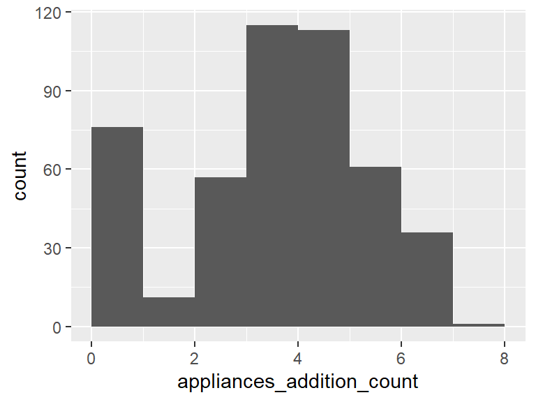

## health_offering_change_count

| Feature | Result |
| --- | --- |
| Variable type | integer |
| Number of missing obs. | 0 (0 %) |
| Number of unique values | 6 |
| Median | 0 |
| 1st and 3rd quartiles | 0; 2 |
| Min. and max. | 0; 5 |

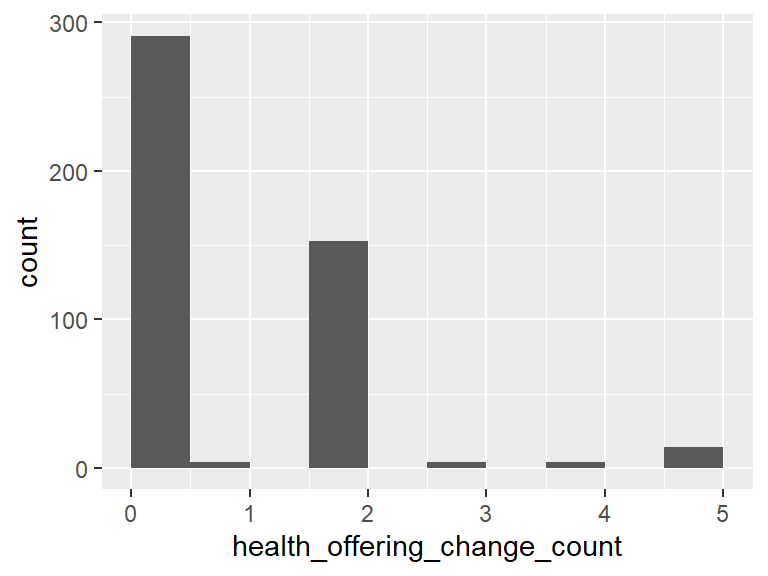

Report generation information:

- Created by: Akoua Orsot~ (username: `User`).
- Report creation time: Fri Oct 06 2023 11:43:33
- Report was run from directory: `\\wsl.localhost/Ubuntu/home/aorsot/Renewvia/survey_impact_analysis`
- dataMaid v1.4.1 [Pkg: 2021-10-08 from CRAN (R 4.3.1)]
- R version 4.3.1 (2023-06-16 ucrt).
- Platform: x86_64-w64-mingw32/x64 (64-bit)(Etc/UTC).
- Function call: `makeDataReport(data = ci_post_clean, output = "html", replace = TRUE)`